# Assignment

Juan Pablo NAVARRO RUEDA - 20021160

21 May, 2020

## 1.Plagiarism

By including this statement, I Juan Pablo Navarro Rueda verify that:

- I hold a copy of this assignment that I can produce if the original is lost or damaged.
- I hereby certify that no part of this assignment has been copied from any other student’s work or from any other source except where due acknowledgement is made in the assignment.
- No part of this assignment has been written/produced for me by another person except where such collaboration has been authorised by the subject lecturer/tutor concerned.
- I am aware that this work may be reproduced and submitted to plagiarism detection software programs for the purpose of detecting possible plagiarism (which may retain a copy on its database for future plagiarism checking).
- I hereby certify that I have read and understood what the School of Computing, Engineering and Mathematics defines as minor and substantial breaches of misconduct as outlined in the learning guide for this unit.

[figure not shown]

From: https://images.app.goo.gl/QYh7jY4sFVJ9pki56

## 2.Manipulating Arrays

A vector with the function `runif` was created which by default creates a vector of random number from 0 to 1.

```r
studentno <- 20021160
set.seed(studentno)
my_vector <- runif(35)
my_vector
```

```
 [1] 0.35223371 0.59658958 0.65312196 0.98357452 0.77701926 0.70313336
 [7] 0.50758480 0.26532392 0.44403021 0.39709584 0.46616952 0.93620896
[13] 0.04005506 0.23614717 0.55255044 0.73297769 0.89283853 0.19287519
[19] 0.13273840 0.47640514 0.73660637 0.31559448 0.46313193 0.44463288
[25] 0.22465172 0.28949110 0.48673550 0.50403265 0.74393359 0.25668538
[31] 0.15446546 0.69002130 0.18461105 0.49638014 0.13050769
```

When the vector is created, a summary of it is displayed with the format presented in the assignment guide. First, the function `summary` is used to store some statistical details in the variable `suma` this details for vectors are:

- Minimum value
- First quantile
- Median
- Mean
- Third quantile
- Maximum value

the `cat` function is used to create the format and with the variable `suma`, the requiered values were presented.

```r
suma <- summary(my_vector)
cat("Minimum value:",suma[["Min."]],"\tMaximum value:", suma[["Max."]],"\nAverage value:", suma[["Mean"]],"\tMedian value:",suma[["Median"]])
```

```
Minimum value: 0.04005506   Maximum value: 0.9835745
Average value: 0.4702901    Median value: 0.4661695
```

A random number between 8 and 12 is selected with the function `sample`, this number is assigned to varible `n` which will represent the nth smallest value and nth largest value. In order to find these last two values first the vector is sorted with the function `sort` twice and returning the nth value. However, the second time the `decreasing` argument is added to the function to have the vector sorted from the largest value to the smallest.

```r
n <- sample(8:12,1)
nth <- paste(n,"th",sep="")
cat("The",nth,"smallest value is:", sort(my_vector)[n],"\nThe",nth,"largest value is:",sort(my_vector,decreasing = TRUE)[n])
```

```
The 8th smallest value is: 0.2361472
The 8th largest value is: 0.7031334
```

The vector now is reshaped to a 5 by 7 matrix with the function `matrix`. To know which column has the largest sum the function `order` with the function `apply` were used. the function `apply` first creates a vector with the sum of all the columns in order of columns, for instance, the first column sum is the first element of the output vector of the function `apply`. Then the function `order` returns the indexes of, in this case, the vector of the sums of each column sorted, which represent the column itself. similar to the `sort` function but with indexes. The same functions were applied for the sum of each row.

```r
mat <- matrix(my_vector,nrow = 5,ncol = 7)
lgst_sum <- order(apply(mat,2,sum),decreasing = T)[1]
smst_sum <- order(apply(mat,1,sum))[1]
cat("Column",lgst_sum,"has the largest sum of all columns","\nRow",smst_sum,"has the smallest sum of all rows")
```

```
Column 1 has the largest sum of all columns
Row 3 has the smallest sum of all rows
```

The values of mat[i,j] that are grater than 0.4 are replaced for mat[i,j]-1. This is done in the first line. The last step is sum all the elements in the matrix with the function `sum` and present the results in the requiered format.

```r
mat[mat>=0.4]=mat[mat>=0.4]-1
sum_mat <- sum(mat)
cat("The sum of the new matrix is",sum_mat)
```

```
The sum of the new matrix is -4.539845
```

## 3. Plotting

```r
library(R.matlab)
A <- readMat('Data/paviauni.mat')
```

Using the function `dim` the dimmension of the array are displayed

```r
cat("A$X is",dim(A$X)[1],"by",dim(A$X)[2],"by",dim(A$X)[3])
```

```
A$X is 610 by 340 by 103
```

```r
cat("A$groundtruth is", dim(A$groundtruth)[1],"by",dim(A$groundtruth)[2])
```

```
A$groundtruth is 610 by 340
```

To present the classes in the matrix `A$groundthruth` is possible to use table, however, to present them in the format requiered a for loop is implemented.

```r
for(i in 0:9){
  cat("Class",paste0(i,":"),table(A$groundtruth)[i+1],"pixels\n")
}
```

```
Class 0: 164624 pixels
Class 1: 6631 pixels
Class 2: 18649 pixels
Class 3: 2099 pixels
Class 4: 3064 pixels
Class 5: 1345 pixels
Class 6: 5029 pixels
Class 7: 1330 pixels
Class 8: 3682 pixels
Class 9: 947 pixels
```

For this last task two lists are created in order to store all the arrays and the indexes in it as it is done in the list `A` that is used for this question. an array of a sample of 25 indexes is created per class in `A$grountruth` and stored in `inde`. Another with the data from `A$X` with the specific indexes from `inde` is assigned to `plots` and finally all the lines are ploted with the functions `plot` and `line`. with `plot` the window is created and `lines` add the 24 extra lines that had not been ploted.

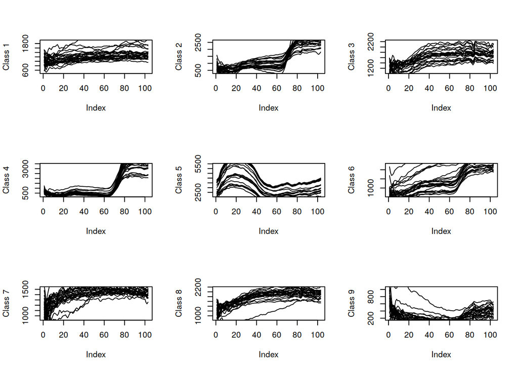

```r
inde=list()
plots = list()
par(mfrow=c(3,3))
for (i in 1:9) {
  inde[[i]] = which(A$groundtruth==i, arr.ind = T)
  inde[[i]] = inde[[i]][sample(1:nrow(inde[[i]]),25,F),]
  plots[[i]] = A$X[inde[[i]][,1],inde[[i]][,2],]
  plot(plots[[i]][1,1,],type="l",ylab = paste("Class",i))
  for (j in 2:25){
    lines(plots[[i]][j,j,])
  }
}
```

## 4.Predicting coin flips

```r
ran_seq <- c(0,1,0,1,1,0,0,1,0,1,1,0,0,0,0,1,0,1,0,1,0,1,1,1,0,0,0,0,1,1,0,1,0,0,1,0,0,0,0,1,0,0,1,0,0,1,0,1,0,0,1)
cat("My fake sequence:",ran_seq)
```

```
My fake sequence: 0 1 0 1 1 0 0 1 0 1 1 0 0 0 0 1 0 1 0 1 0 1 1 1 0 0 0 0 1 1 0 1 0 0 1 0 0 0 0 1 0 0 1 0 0 1 0 1 0 0 1
```

with the function `diff` the number of times the vector `ran_seq` has fluctuations is found.

```r
dife <- abs(diff(ran_seq))
nf <- sum(dife)
cat("The sequence of flips fluctuates nf =",nf,"times.")
```

```
The sequence of flips fluctuates nf = 31 times.
```

the fluctuations is simulated 10^5 times with the function `replicate`. A sample of 51 elements with replacement of the vector `c(0,1)` is created for this porpouse. Finally the results are presented in a histogram.

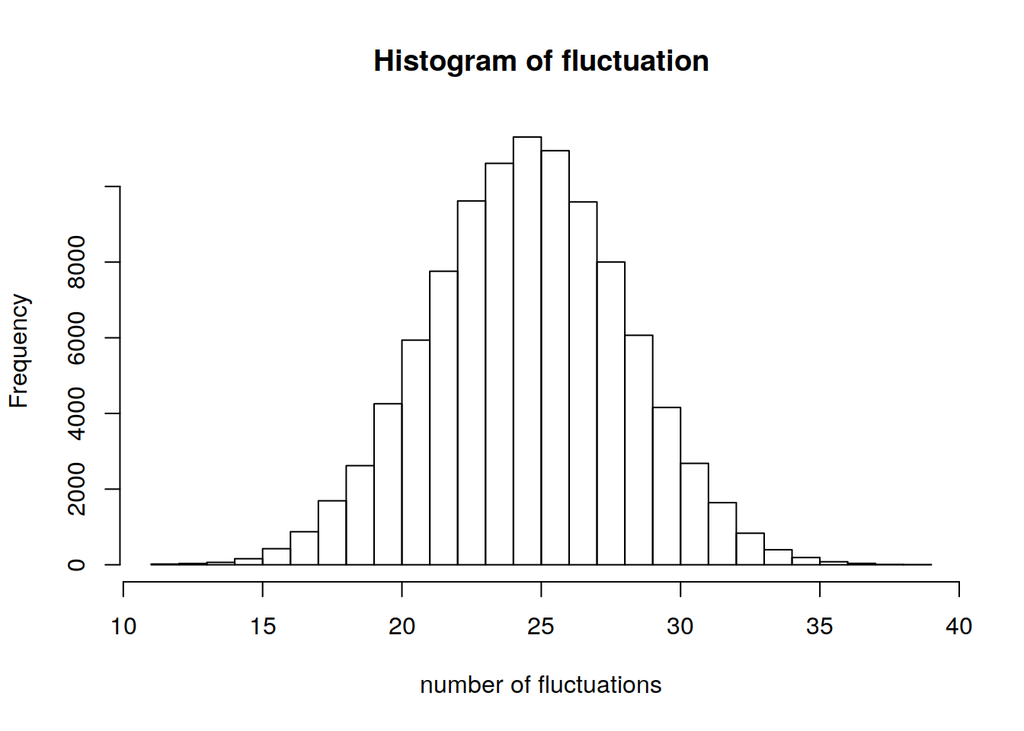

```r
fluctuation <- replicate(10^5,{sum(abs(diff(sample(c(0,1),51,replace = T))))})
hist(fluctuation,breaks = 22,xlab = "number of fluctuations")
```

```r
D=abs(nf-25)
perc <- (length(fluctuation[fluctuation>=25+D])+length(fluctuation[fluctuation<=25-D]))*100/length(fluctuation)
cat(paste0(perc,"%"),"of trials have fluctuations that are >=",D,"away from average.")
```

```
11.757% of trials have fluctuations that are >= 6 away from average.
```

Coins game:

```r
#Money variable with $10 and guesses vector with 2 values to calculate the first toss
money<-10
guesses<-sample(c(0,1),2,T)
#A flag is created for the game to know when an input is incorrect
f = T
while(money>0 &&length(guesses)<=53){
  #The user is asked for an input "h" or "t"
  cat("\ninput 'h' if your guess is heads and 't' if it is tails")
  your_current_guess<- readLines(con = stdin(),n=1)
  #Checking if is not an incorrect input
  if(your_current_guess != "h" && your_current_guess!="t"){
    f=F
    break
  }
  #Adding the user selection
  guesses<-append(guesses,your_current_guess,after = 0)
  #changing "h" for 1 and "t" for 0
  guesses[guesses=="h"] = 1
  guesses[guesses=="t"] = 0
  guesses <- as.integer(guesses)
  #Assigning the value pf
  if (length(guesses)<=5){
    pf=0.7
  }else{
    dife_user <- abs(diff(guesses))
    pf <- sum(dife_user)/length(dife_user)
  }
  if (runif(1) < pf){
    thistoss = guesses[2]
  } else {
    thistoss = 1-guesses[2]
  }
  if (guesses[1]==thistoss){ #Checking if the guess is correct and updating money
    money=money+1
    cat("correct, you win $1 your money at the moment is",paste0("$",money))
  }else{
    money=money-1
    cat("incorrect, you lost $1, your money at the moment is",paste0("$",money))
  }
}
#Checking why the while loop broke
if(money == 0){
  cat("\nSorry, you have lost")
}else if(f){
  cat("\ncongratulation, you win $",money)
}else{
  cat("\nyou input a wrong option")
}
```